# Data analysis in R- Bellabeat

Yun-Chin(Verna) Lee

2023-02-25

## Introduction of the Project

This is project is to help Bellabeat, a high-tech manufacturer of health-focused products for women, to gain insight into how consumers are using their smart devices. *The insights will then help guide marketing strategy for the company.*

## Project Goal

Find out **the trends in smart device usage** and **how these trends could apply to Bellabeat customers**. Furthermore, point out **how these trends could help influence Bellabeat marketing strategy**.

## Source of Data Set

[FitBit Fitness Tracker Data](https://www.kaggle.com/datasets/arashnic/fitbit) (CC0: Public Domain, dataset made available through [Mobius](https://www.kaggle.com/arashnic)): This Kaggle data set contains personal fitness tracker from thirty fitbit users. Thirty eligible Fitbit users consented to the submission of personal tracker data, including minute-level output for physical activity, heart rate, and sleep monitoring. It includes information about daily activity, steps, and heart rate that can be used to explore users’ habits.

## Loading Packages

First thing first, we need to load the packages which will be used throughout the project.

```r
install.packages("tidyverse", repos = "http://cran.us.r-project.org")
library(tidyr)
library(dplyr)
```

```r
library(ggplot2)
library(readr)
library(purrr)
```

## Importing Data

After loading the packages, let’s import the datasets. Since we are given 18 data sets, I decided to check all of them in Excel beforehand to better understand which data sets to use. Following are my chosen data sets and the reasons why I chose them.

*dailyActivity_merged This data set contains data of dailyCalories_merged, dailyIntensities_merged and dailySteps_merged. It should be useful for us to find out the user trend.

*hourlyIntensities_merged and hourlySteps_merged Both hourlyIntensities and hourlySteps can help us to know when users tend to engage in more physically required activities. Also, I’d like to find the correlation between these two data sets.

*hourlyCalories_merged HourlyCalories can help us to know the users’ calorie-burning routine better. In addition, we can find out how highly it is correlated to hourlyIntensities and hourlySteps. By knowing the correlation, we can better recommend the activities to participate in if our user wants to burn more calories.

*sleepDay_merged SleepDay_merged is useful to help us to understand users’ sleeping habit.

```r
setwd("/Users/leeverna/Downloads/Fitabase Data 4.12.16-5.12.16/To use")
daily_activity <- read_csv('dailyActivity_merged.csv')
hourly_intensities <- read_csv('hourlyIntensities_merged.csv')
hourly_steps <- read_csv('hourlySteps_merged.csv')
hourly_calories <- read_csv('hourlyCalories_merged.csv')
sleep <- read_csv('sleepDay_merged.csv')
```

The data set weightLogInfo_merged seems useful for defining the target audiences. However, after checking it with pivot table in Excel, I realized it only contains 8 users’ data, which is very far from the metadata provided from the data source that claims the data includes information of 30 users. For the sake of data integrity and the accuracy of our analysis, we won’t use the data set weightLogInfo_merged.

## Data Exploration

Firstly, let’s check the head and data type of our data sets to see if any cleaning needed in the next step.

```r
# Daily activity
head(daily_activity)
```

```
## # A tibble: 6 × 15
##       Id Activ…¹ Total…² Total…³ Track…⁴ Logge…⁵ VeryA…⁶ Moder…⁷ Light…⁸ Seden…⁹
##    <dbl> <chr>     <dbl>   <dbl>   <dbl>   <dbl>   <dbl>   <dbl>   <dbl>   <dbl>
## 1 1.50e9 4/12/2…   13162    8.5     8.5        0    1.88   0.550    6.06       0
## 2 1.50e9 4/13/2…   10735    6.97    6.97       0    1.57   0.690    4.71       0
## 3 1.50e9 4/14/2…   10460    6.74    6.74       0    2.44   0.400    3.91       0
## 4 1.50e9 4/15/2…    9762    6.28    6.28       0    2.14   1.26     2.83       0
## 5 1.50e9 4/16/2…   12669    8.16    8.16       0    2.71   0.410    5.04       0
## 6 1.50e9 4/17/2…    9705    6.48    6.48       0    3.19   0.780    2.51       0
## # … with 5 more variables: VeryActiveMinutes <dbl>, FairlyActiveMinutes <dbl>,
## #   LightlyActiveMinutes <dbl>, SedentaryMinutes <dbl>, Calories <dbl>, and
## #   abbreviated variable names ¹ActivityDate, ²TotalSteps, ³TotalDistance,
## #   ⁴TrackerDistance, ⁵LoggedActivitiesDistance, ⁶VeryActiveDistance,
## #   ⁷ModeratelyActiveDistance, ⁸LightActiveDistance, ⁹SedentaryActiveDistance
```

```r
# Hourly intensities
head(hourly_intensities)
```

```
## # A tibble: 6 × 4
##           Id ActivityHour          TotalIntensity AverageIntensity
##        <dbl> <chr>                          <dbl>            <dbl>
## 1 1503960366 4/12/2016 12:00:00 AM             20            0.333
## 2 1503960366 4/12/2016 1:00:00 AM               8            0.133
## 3 1503960366 4/12/2016 2:00:00 AM               7            0.117
## 4 1503960366 4/12/2016 3:00:00 AM               0            0
## 5 1503960366 4/12/2016 4:00:00 AM               0            0
## 6 1503960366 4/12/2016 5:00:00 AM               0            0
```

```r
# Hourly steps
head(hourly_steps)
```

```
## # A tibble: 6 × 3
##           Id ActivityHour          StepTotal
##        <dbl> <chr>                     <dbl>
## 1 1503960366 4/12/2016 12:00:00 AM       373
## 2 1503960366 4/12/2016 1:00:00 AM        160
## 3 1503960366 4/12/2016 2:00:00 AM        151
## 4 1503960366 4/12/2016 3:00:00 AM          0
## 5 1503960366 4/12/2016 4:00:00 AM          0
## 6 1503960366 4/12/2016 5:00:00 AM          0
```

```r
# Hourly calories
head(hourly_calories)
```

```
## # A tibble: 6 × 3
##           Id ActivityHour          Calories
##        <dbl> <chr>                    <dbl>
## 1 1503960366 4/12/2016 12:00:00 AM       81
## 2 1503960366 4/12/2016 1:00:00 AM        61
## 3 1503960366 4/12/2016 2:00:00 AM        59
## 4 1503960366 4/12/2016 3:00:00 AM        47
## 5 1503960366 4/12/2016 4:00:00 AM        48
## 6 1503960366 4/12/2016 5:00:00 AM        48
```

```r
# Sleep
head(sleep)
```

```
## # A tibble: 6 × 5
##           Id SleepDay              TotalSleepRecords TotalMinutesAsleep TotalT…¹
##        <dbl> <chr>                             <dbl>              <dbl>    <dbl>
## 1 1503960366 4/12/2016 12:00:00 AM                 1                327      346
## 2 1503960366 4/13/2016 12:00:00 AM                 2                384      407
## 3 1503960366 4/15/2016 12:00:00 AM                 1                412      442
## 4 1503960366 4/16/2016 12:00:00 AM                 2                340      367
## 5 1503960366 4/17/2016 12:00:00 AM                 1                700      712
## 6 1503960366 4/19/2016 12:00:00 AM                 1                304      320
## # … with abbreviated variable name ¹TotalTimeInBed
```

I noticed ActivityDate and ActivityHour in all of our data sets are string values instead of time. This should be corrected later on.

Secondly, let’s check if there’s any duplicate. We will need to remove them if any.

```r
sum(duplicated(daily_activity))
```

```
## [1] 0
```

```r
sum(duplicated(hourly_intensities))
```

```
## [1] 0
```

```r
sum(duplicated(hourly_steps))
```

```
## [1] 0
```

```r
sum(duplicated(hourly_calories))
```

```
## [1] 0
```

```r
sum(duplicated(sleep))
```

```
## [1] 3
```

3 duplicates are found in sleep dataframe. Let’s remove them before proceeding.

```r
sleep_d <- distinct(sleep)
sum(duplicated(sleep_d))
```

```
## [1] 0
```

Now our data sets are looking good to proceed! Let’s have a look at the statistic summery of our data sets to get a better idea of our users.

```r
# Daily activity
daily_activity %>%
  select(TotalSteps,
         TotalDistance,
         VeryActiveDistance,
         VeryActiveMinutes,
         LightActiveDistance,
         LightlyActiveMinutes,
         SedentaryMinutes,
         Calories) %>%
  summary()
```

```
##    TotalSteps    TotalDistance    VeryActiveDistance VeryActiveMinutes
##  Min.   :    0   Min.   : 0.000   Min.   : 0.000     Min.   :  0.00
##  1st Qu.: 3790   1st Qu.: 2.620   1st Qu.: 0.000     1st Qu.:  0.00
##  Median : 7406   Median : 5.245   Median : 0.210     Median :  4.00
##  Mean   : 7638   Mean   : 5.490   Mean   : 1.503     Mean   : 21.16
##  3rd Qu.:10727   3rd Qu.: 7.713   3rd Qu.: 2.053     3rd Qu.: 32.00
##  Max.   :36019   Max.   :28.030   Max.   :21.920     Max.   :210.00
##  LightActiveDistance LightlyActiveMinutes SedentaryMinutes    Calories
##  Min.   : 0.000      Min.   :  0.0        Min.   :   0.0   Min.   :   0
##  1st Qu.: 1.945      1st Qu.:127.0        1st Qu.: 729.8   1st Qu.:1828
##  Median : 3.365      Median :199.0        Median :1057.5   Median :2134
##  Mean   : 3.341      Mean   :192.8        Mean   : 991.2   Mean   :2304
##  3rd Qu.: 4.782      3rd Qu.:264.0        3rd Qu.:1229.5   3rd Qu.:2793
##  Max.   :10.710      Max.   :518.0        Max.   :1440.0   Max.   :4900
```

```r
# Hourly intensities
hourly_intensities %>%
  select(TotalIntensity) %>%
  summary()
```

```
##  TotalIntensity
##  Min.   :  0.00
##  1st Qu.:  0.00
##  Median :  3.00
##  Mean   : 12.04
##  3rd Qu.: 16.00
##  Max.   :180.00
```

```r
# Hourly steps
hourly_steps %>%
  select(StepTotal) %>%
  summary()
```

```
##    StepTotal
##  Min.   :    0.0
##  1st Qu.:    0.0
##  Median :   40.0
##  Mean   :  320.2
##  3rd Qu.:  357.0
##  Max.   :10554.0
```

```r
# Hourly calories
hourly_calories %>%
  select(Calories) %>%
  summary()
```

```
##     Calories
##  Min.   : 42.00
##  1st Qu.: 63.00
##  Median : 83.00
##  Mean   : 97.39
##  3rd Qu.:108.00
##  Max.   :948.00
```

```r
# Sleep
sleep_d %>%
  select(TotalMinutesAsleep,
         TotalTimeInBed) %>%
  summary()
```

```
##  TotalMinutesAsleep TotalTimeInBed
##  Min.   : 58.0      Min.   : 61.0
##  1st Qu.:361.0      1st Qu.:403.8
##  Median :432.5      Median :463.0
##  Mean   :419.2      Mean   :458.5
##  3rd Qu.:490.0      3rd Qu.:526.0
##  Max.   :796.0      Max.   :961.0
```

## Cleaning Data

During data exploration, we found that time data is wrongly typed as string. Thus, we need to correct them.

```r
daily_activity$ActivityDate <- as.POSIXct(daily_activity$ActivityDate, format="%m/%d/%Y", tz=Sys.timezone())
hourly_intensities$ActivityHour <- as.POSIXct(hourly_intensities$ActivityHour, format="%m/%d/%Y %I:%M:%S %p", tz=Sys.timezone())
hourly_steps$ActivityHour <- as.POSIXct(hourly_steps$ActivityHour, format="%m/%d/%Y %I:%M:%S %p", tz=Sys.timezone())
hourly_calories$ActivityHour <- as.POSIXct(hourly_calories$ActivityHour, format="%m/%d/%Y %I:%M:%S %p", tz=Sys.timezone())
sleep_d$SleepDay <- as.POSIXct(sleep_d$SleepDay, format="%m/%d/%Y %I:%M:%S %p", tz=Sys.timezone())
```

## Finding out the user’s daily routine

By matching user ID and activity hour, we can plot to see what the daily physical activity schedule looks like for users.

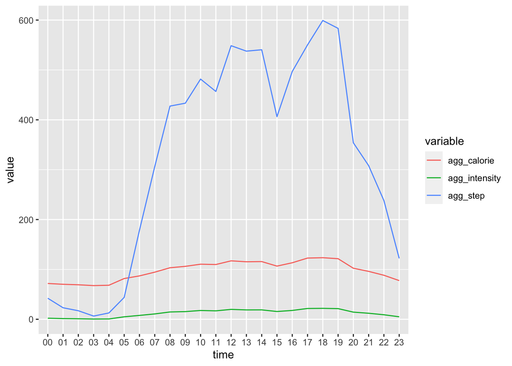

```r
# Merging hourly_intensities, hourly_steps and hourly_calories by user ID and activity hour
hourly_list <- list(hourly_intensities, hourly_steps, hourly_calories)
hourly_data  <- hourly_list %>% reduce(inner_join, by=c('Id','ActivityHour'))
# Separate the date-time column and removed the combined one
hourly_data$date <- as.Date(hourly_data$ActivityHour)
hourly_data$time <- format(as.POSIXct(hourly_data$ActivityHour), format = '%H')
hourly_data_a <- hourly_data %>% select(-c(ActivityHour))
hourly_data_f <- select(hourly_data, Id, date, time, TotalIntensity, StepTotal, Calories)
# Get hourly average of TotalIntensity, StepTotal and Calories
hourly_data_tr <- hourly_data_f %>% group_by(time) %>% summarize(
  agg_intensity = mean(TotalIntensity),
  agg_step = mean(StepTotal),
  agg_calorie = mean(Calories))
# Plotting dataframe
hourly_data_tr %>%
  pivot_longer(cols = 4:2,
               names_to = 'variable',
               values_to = 'value') %>%
  ggplot(aes(x=time, y=value, group=variable)) +
  geom_line(aes(color=variable))
```

According to the line graph, we can see that our users are active from 6am to 11pm. Plus, steps peak at 6pm. Other than this, we can notice that intensive activity seems to have a strong positive correlation to calorie consumption. Let’s plot their correlation to find out their correlation.

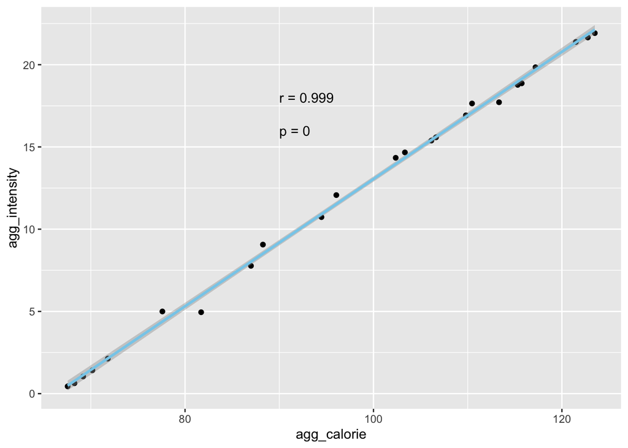

```r
# Correlation between calorie and intensity
r_intensity <- round(cor(hourly_data_tr$agg_intensity, hourly_data_tr$agg_calorie), 3)
p_intensity <- cor.test(hourly_data_tr$agg_intensity, hourly_data_tr$agg_calorie)$p.value
ggplot(hourly_data_tr, aes(y=agg_intensity, x=agg_calorie)) +
  geom_point() +
  geom_smooth(method="lm", col="skyblue") +
  annotate("text", x=90, y=18, label=paste0("r = ", r_intensity), hjust=0) +
  annotate("text", x=90, y=16, label=paste0("p = ", round(p_intensity, 3)), hjust=0)
```

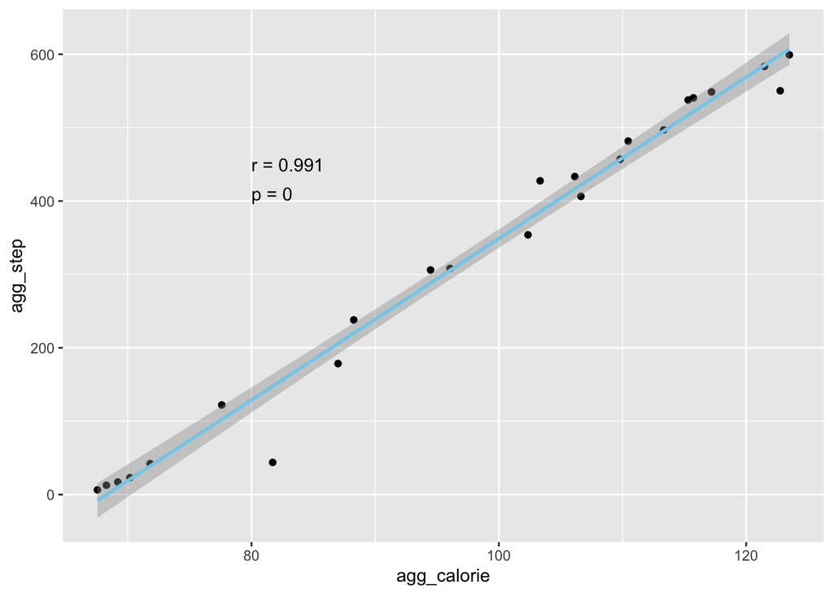

```r
# Correlation between calorie and step
r_step <- round(cor(hourly_data_tr$agg_step, hourly_data_tr$agg_calorie), 3)
p_step <- cor.test(hourly_data_tr$agg_step, hourly_data_tr$agg_calorie)$p.value
ggplot(hourly_data_tr, aes(y=agg_step, x=agg_calorie)) +
  geom_point() +
  geom_smooth(method="lm", col="skyblue") +
  annotate("text", x=80, y=450, label=paste0("r = ", r_step), hjust=0) +
  annotate("text", x=80, y=410, label=paste0("p = ", round(p_step, 3)), hjust=0)
```

Although the correlation between steps taken and calorie consumption is less than it is with intensive activity, with correlation coefficient of 0.991, we can conclude that the two are indeed positively highly correlated. **These two insights can help our users better choosing their activity based on their needs, e.g. if one is seeking for losing weight, step counting in the app might be helpful but setting a daily alarm for reminding the user to do workout is going to give a greater aid.**

## Sleep analysis

```r
# Merging daily_activity and sleep_d
colnames(sleep_d)[2] <- "Date"
colnames(daily_activity)[2] <- "Date"
sleep_activity_list <- list(sleep_d, daily_activity)
sleep_activity <- sleep_activity_list %>% reduce(inner_join, by=c('Id','Date'))
# Get average for each user's daily data
sleep_activity_tr <- sleep_activity %>% group_by(Id) %>% summarize(
  agg_sleep = mean(TotalMinutesAsleep),
  agg_inbed = mean(TotalTimeInBed),
  agg_fallasleep = (agg_inbed - agg_sleep),
  agg_steps = mean(TotalSteps),
  agg_veryactivemins = mean(VeryActiveMinutes),
  agg_calories = mean(Calories))
```

After preparing our data, let’s find the correlation of steps taken, active minutes and calorie consumption with time to fall asleep respectively.

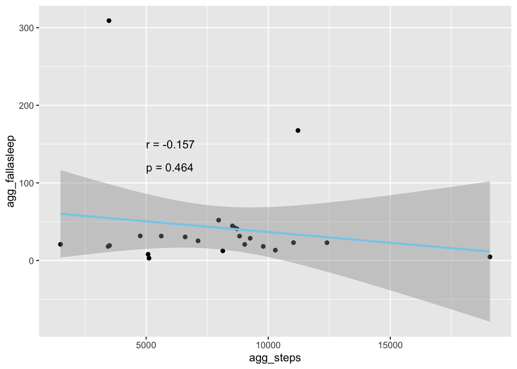

```r
# Correlation between agg_fallasleep and agg_steps
r_intensity <- round(cor(sleep_activity_tr$agg_fallasleep, sleep_activity_tr$agg_steps), 3)
p_intensity <- cor.test(sleep_activity_tr$agg_fallasleep, sleep_activity_tr$agg_steps)$p.value
ggplot(sleep_activity_tr, aes(y=agg_fallasleep, x=agg_steps)) +
  geom_point() +
  geom_smooth(method="lm", col="skyblue") +
  annotate("text", x=5000, y=150, label=paste0("r = ", r_intensity), hjust=0) +
  annotate("text", x=5000, y=120, label=paste0("p = ", round(p_intensity, 3)), hjust=0)
```

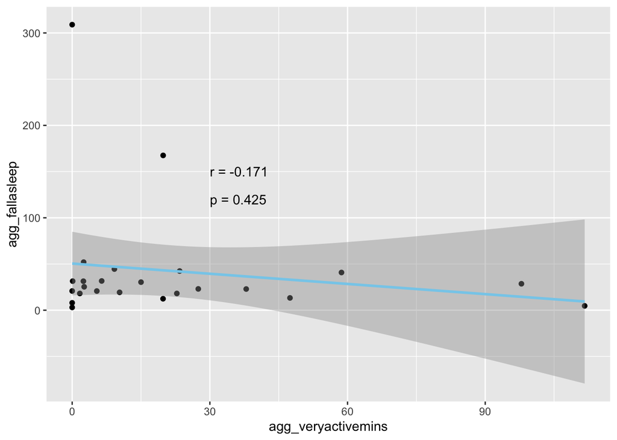

```r
# Correlation between agg_fallasleep and agg_veryactivemins
r_intensity <- round(cor(sleep_activity_tr$agg_fallasleep, sleep_activity_tr$agg_veryactivemins), 3)
p_intensity <- cor.test(sleep_activity_tr$agg_fallasleep, sleep_activity_tr$agg_veryactivemins)$p.value
ggplot(sleep_activity_tr, aes(y=agg_fallasleep, x=agg_veryactivemins)) +
  geom_point() +
  geom_smooth(method="lm", col="skyblue") +
  annotate("text", x=30, y=150, label=paste0("r = ", r_intensity), hjust=0) +
  annotate("text", x=30, y=120, label=paste0("p = ", round(p_intensity, 3)), hjust=0)
```

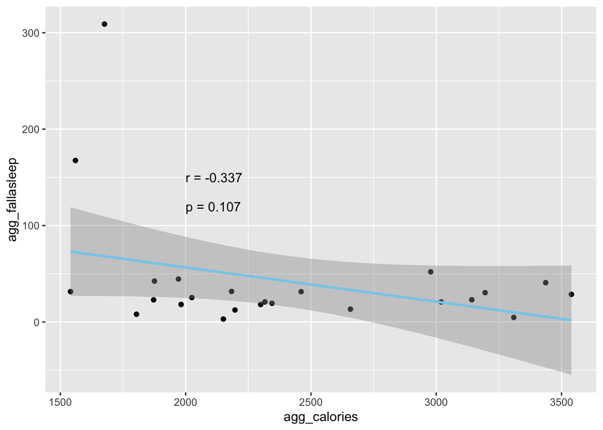

```r
# Correlation between agg_fallasleep and agg_calories
r_intensity <- round(cor(sleep_activity_tr$agg_fallasleep, sleep_activity_tr$agg_calories), 3)
p_intensity <- cor.test(sleep_activity_tr$agg_fallasleep, sleep_activity_tr$agg_calories)$p.value
ggplot(sleep_activity_tr, aes(y=agg_fallasleep, x=agg_calories)) +
  geom_point() +
  geom_smooth(method="lm", col="skyblue") +
  annotate("text", x=2000, y=150, label=paste0("r = ", r_intensity), hjust=0) +
  annotate("text", x=2000, y=120, label=paste0("p = ", round(p_intensity, 3)), hjust=0)
```

## Share insights

Through the analysis, we find our target audience for the smart device is

- having a sedentary lifestyle
- active from 6am to 11pm
- walking the most at 6pm

## Conclusion

For the marketing strategy, we can focus on promoting the device to women with a similar lifestyle as our target audiences, such as office workers, writers, and Uber drivers. The ads are better shown within the time range from 6am to 11pm. Other than that, we can also cooperate with businesses with the same group of customers to reach a larger audience.

As for attracting users, we can ask users to complete a questionnaire while setting the device to get an idea about what they expect to achieve with our product. For example, for users with an interest in losing weight, we can suggest they set an alarm for workouts as well as provide them weekly reports of their physical activity. All in all, showing that our device could be the best assistant for achieving ideal their physical/healthy target.